# ID Ryan (Ran) Wright 305109613

# ID Ben Remez 315470450

# LINK to Github Repo: (https://github.com/RyanWri/afeka-nlp-homeworks)

## repo is private, request access if needed

```python
# Import necessary libraries
import numpy as np
import matplotlib.pyplot as plt
import seaborn as sns
```

# Question 1 Attention & Multi Head Attention

# 1A. Self Attention

```python
def self_attention(queries, keys, values, mask=None):
    """
    Implement vanilla self-attention.

    Parameters:
    - queries (np.ndarray): Query matrix of shape (batch_size, seq_len, d_k).
    - keys (np.ndarray): Key matrix of shape (batch_size, seq_len, d_k).
    - values (np.ndarray): Value matrix of shape (batch_size, seq_len, d_v).
    - mask (np.ndarray or None): Optional mask matrix of shape (batch_size, seq_len, seq_len).

    Returns:
    - np.ndarray: Attention output of shape (batch_size, seq_len, d_v).
    """
    d_k = queries.shape[-1]  # Dimensionality of keys/queries

    # Step 1: Compute attention scores
    scores = np.matmul(
        queries, keys.transpose(0, 2, 1)
    )  # (batch_size, seq_len, seq_len)
    scores /= np.sqrt(d_k)  # Scale scores by sqrt(d_k)

    # Step 2: Apply mask (if provided)
    if mask is not None:
        scores = np.where(mask == 0, -1e9, scores)

    # Step 3: Compute attention weights
    attention_weights = np.exp(scores)
    attention_weights /= attention_weights.sum(axis=-1, keepdims=True)

    # Step 4: Compute the attention output
    attention_output = np.matmul(
        attention_weights, values
    )  # (batch_size, seq_len, d_v)

    return attention_output, attention_weights
```

# 1B. Multi Head Attention

```python
def multi_head_attention(x, num_heads=8):
    """
    Implement multi-head attention with head splitting.

    Parameters:
    - x (np.ndarray): Input tensor of shape (batch_size, seq_len, d_model).
    - num_heads (int): Number of attention heads.

    Returns:
    - np.ndarray: Output tensor of shape (batch_size, seq_len, d_model).
    """
    batch_size, seq_len, d_model = x.shape
    assert d_model % num_heads == 0, "d_model must be divisible by num_heads"

    d_k = d_model // num_heads  # Dimensionality per head

    # Step 1: Linear projection for queries, keys, and values
    queries = x @ np.random.randn(d_model, d_model)
    keys = x @ np.random.randn(d_model, d_model)
    values = x @ np.random.randn(d_model, d_model)

    # Step 2: Split into multiple heads
    queries = queries.reshape(batch_size, seq_len, num_heads, d_k).transpose(0, 2, 1, 3)
    keys = keys.reshape(batch_size, seq_len, num_heads, d_k).transpose(0, 2, 1, 3)
    values = values.reshape(batch_size, seq_len, num_heads, d_k).transpose(0, 2, 1, 3)

    # Step 3: Apply self-attention to each head
    attention_weights_all_heads = []
    attention_outputs = []

    for h in range(num_heads):
        attention_output, attention_weights = self_attention(
            queries[:, h], keys[:, h], values[:, h]
        )
        attention_outputs.append(attention_output)
        attention_weights_all_heads.append(attention_weights)

    # Step 4: Concatenate the heads
    concatenated = np.concatenate(
        attention_outputs, axis=-1
    )  # (batch_size, seq_len, d_model)

    # Concatenate weights for return
    return concatenated, np.array(attention_weights_all_heads)
```

# 1C. Apply both functions to the polysemy example sentences you created as an answer to question 2 in HW2.

```python
# Visualize attention weights
def plot_attention_weights(attention_weights, tokens, title):
    """
    Visualize attention weights as a heatmap.

    Parameters:
    - attention_weights (np.ndarray): Attention weights (seq_len, seq_len).
    - tokens (list of str): Tokens in the sentence.
    - title (str): Title of the plot.
    """
    plt.figure(figsize=(10, 8))
    sns.heatmap(
        attention_weights,
        xticklabels=tokens,
        yticklabels=tokens,
        cmap="viridis",
        annot=True,
    )
    plt.title(title)
    plt.xlabel("Key Tokens")
    plt.ylabel("Query Tokens")
    plt.show()
```

```python
# Define polysemy examples
sentence1 = "The lead actor delivered an incredible performance."
sentence2 = "Exposure to lead is harmful to health."

tokens_sentence1 = sentence1.split()
tokens_sentence2 = sentence2.split()

# Mock embeddings
np.random.seed(42)
embeddings_sentence1 = np.random.rand(1, len(tokens_sentence1), 8)  # d_model = 8
embeddings_sentence2 = np.random.rand(1, len(tokens_sentence2), 8)
```

```python
# Apply self_attention
output_sentence1, weights_sentence1 = self_attention(
    embeddings_sentence1, embeddings_sentence1, embeddings_sentence1
)
output_sentence2, weights_sentence2 = self_attention(
    embeddings_sentence2, embeddings_sentence2, embeddings_sentence2
)
```

### self attention plots

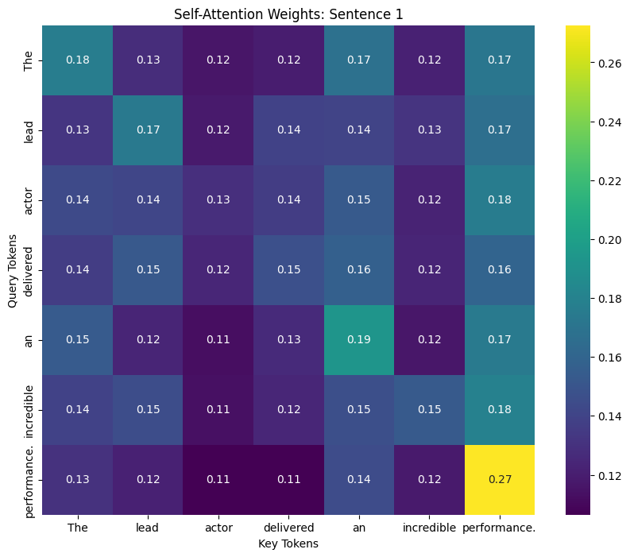

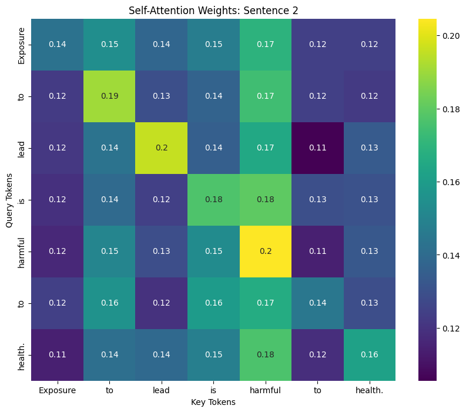

```python
# Visualize attention weights
plot_attention_weights(
    weights_sentence1[0], tokens_sentence1, "Self-Attention Weights: Sentence 1"
)
plot_attention_weights(
    weights_sentence2[0], tokens_sentence2, "Self-Attention Weights: Sentence 2"
)
```

### multi head plots

```python
# Apply multi_head_attention
multi_head_output1, multi_head_weights1 = multi_head_attention(embeddings_sentence1)
multi_head_output2, multi_head_weights2 = multi_head_attention(embeddings_sentence2)
```

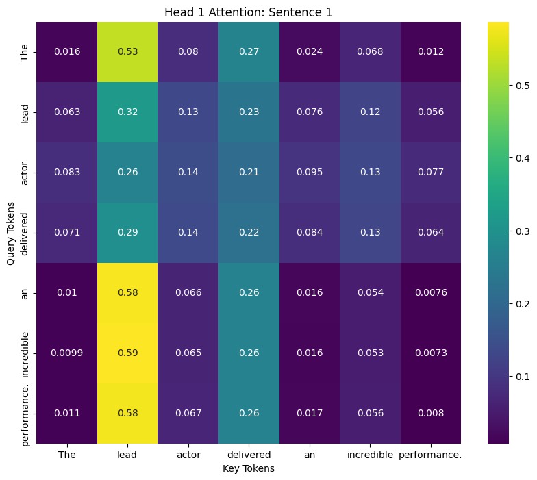

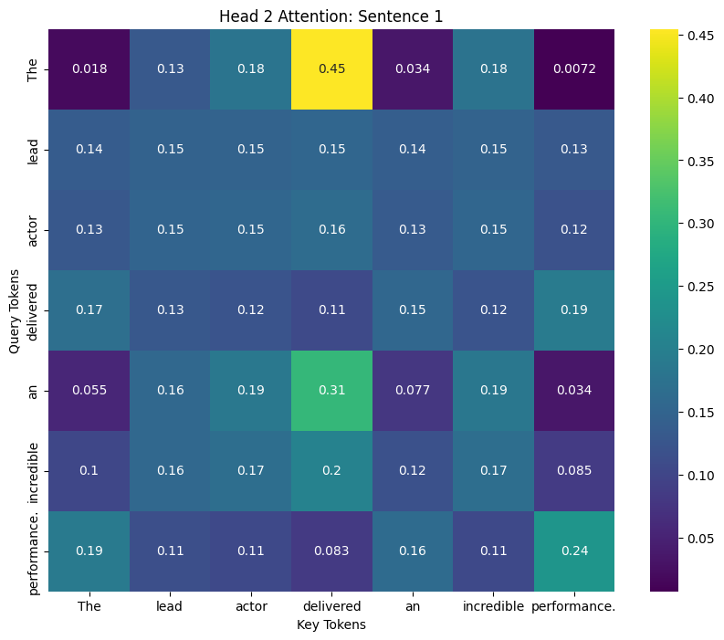

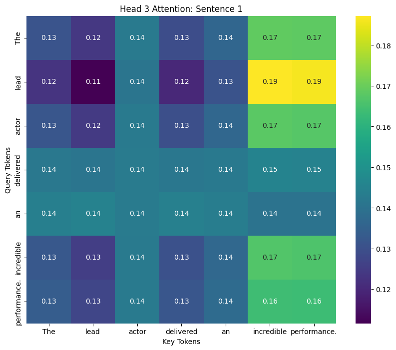

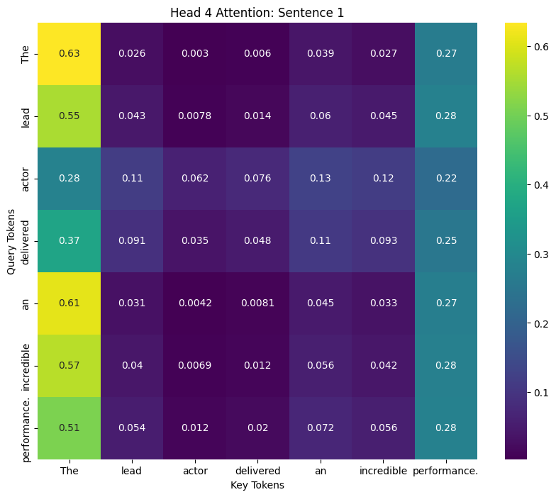

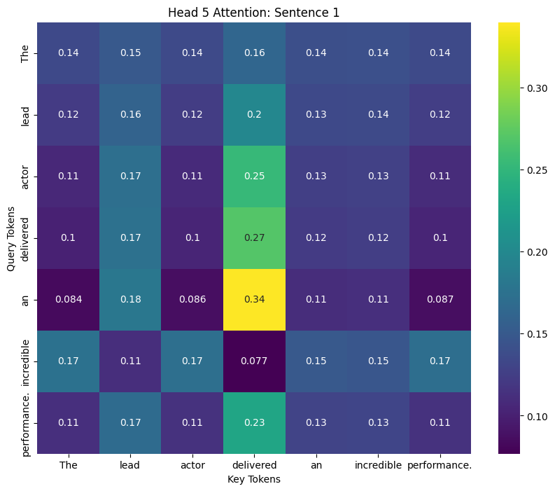

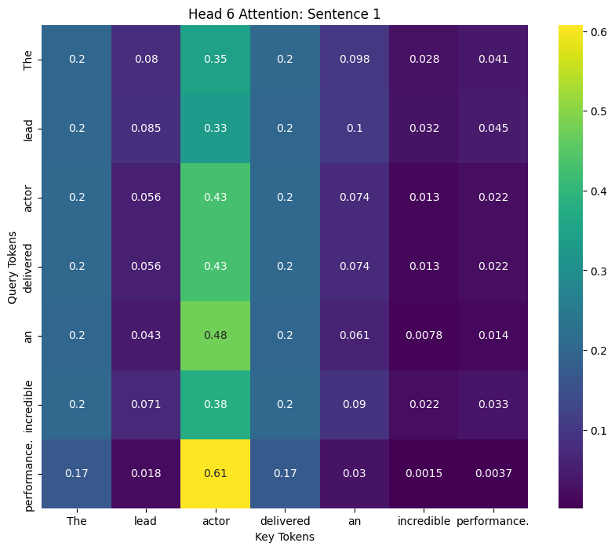

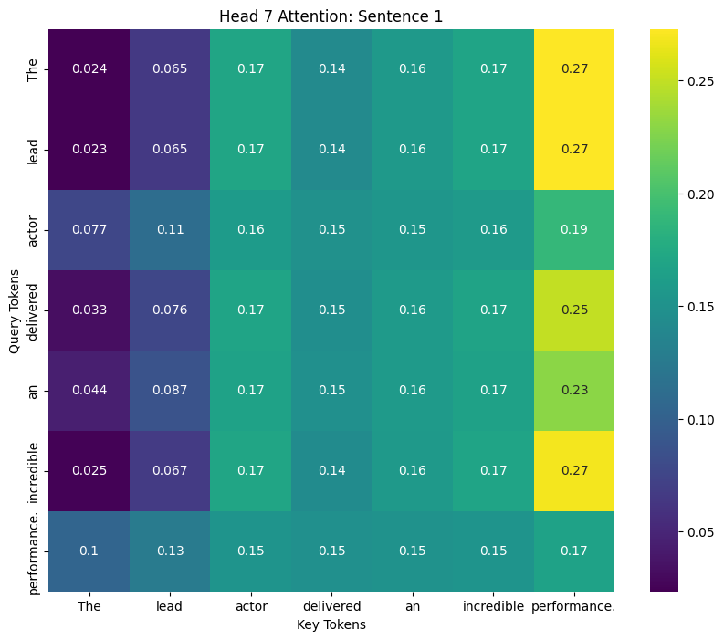

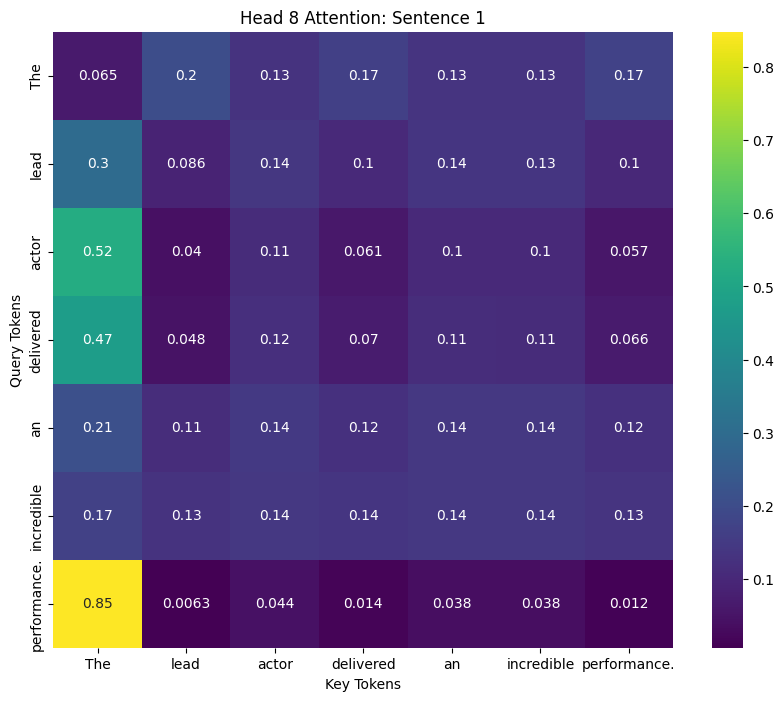

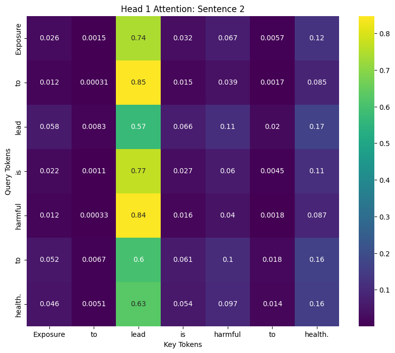

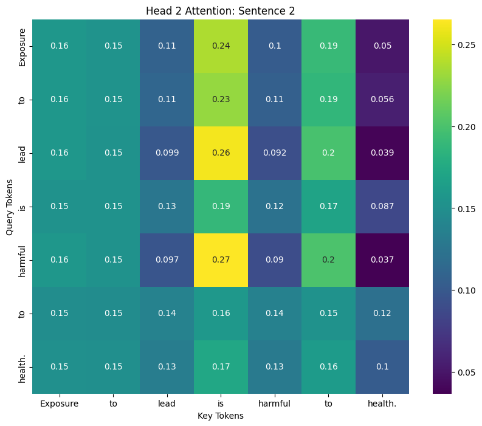

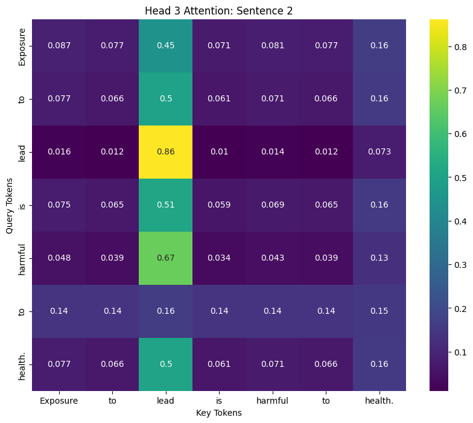

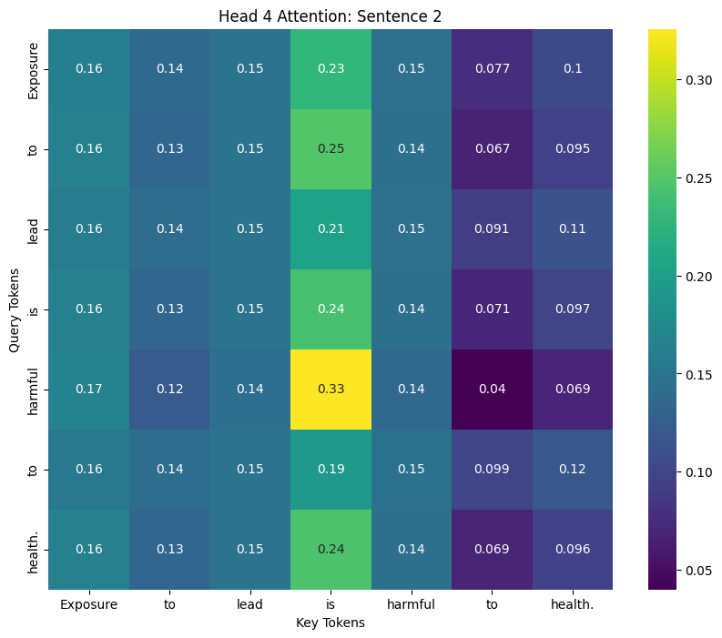

[4 more figures not shown]

```python
# Visualize attention weights for each head
for i in range(multi_head_weights1.shape[0]):  # Iterate over heads
    plot_attention_weights(
        multi_head_weights1[i][0],
        tokens_sentence1,
        f"Head {i + 1} Attention: Sentence 1",
    )

for i in range(multi_head_weights2.shape[0]):  # Iterate over heads
    plot_attention_weights(
        multi_head_weights2[i][0],
        tokens_sentence2,
        f"Head {i + 1} Attention: Sentence 2",
    )
```

------------------------------------------------------------------------------------------------------------------------------------------------

# Question 3: Why Multi-Head Attention is More Effective

### 1. Background: Single vs. Multi-Head Attention

- **Single Attention**: Uses a single query-key-value mechanism for all input embeddings.
- **Multi-Head Attention**: Splits the input embeddings into smaller subspaces (e.g., 8 heads with `d_head = d_model / 8`), computes attention for each head, and concatenates the results.

### 2. Assumptions

Let:

- `d_model`: Dimensionality of input embeddings (same for single and multi-head attention).
- `H`: Number of attention heads.
- `d_head = d_model / H`: Dimensionality per head.
- `n`: Sequence length.

For simplicity, the attention mechanism cost is dominated by:

1. **Dot-product computations** (queries × keys).
2. **Matrix multiplications** (attention weights × values).

### 3. Computational Costs

#### Single-Head Attention:

1. Compute dot product between `Q` and `K^T`: Cost_dot_product = O(n^2 * d_model)
2. Apply softmax and multiply by `V`: Cost_softmax_multiply = O(n^2 * d_model) **Total**: Cost_single = O(n^2 * d_model)

#### Multi-Head Attention:

Each head operates in a subspace of size `d_head = d_model / H`.

1. Compute dot product between `Q_h` and `K_h^T` for each head: Cost_dot_product_head = O(n^2 * d_head) For `H` heads: Cost_dot_product_multi = H * O(n^2 * d_head) = O(n^2 * d_model)
2. Apply softmax and multiply by `V_h` for each head: Cost_softmax_multiply_multi = H * O(n^2 * d_head) = O(n^2 * d_model) **Total**: Cost_multi = O(n^2 * d_model)

### 4. Why Multi-Head is More Effective

#### 4.1 Diverse Subspace Learning

- Multi-head attention splits `d_model` into smaller subspaces (`d_head`).
- Each head learns different aspects of the input:
  - One head might focus on positional relationships.
  - Another might emphasize semantic similarity.
- Single-head attention has a single focus, limiting its expressive power.

#### 4.2 Interaction with Queries, Keys, and Values

- Multi-head attention enables each head to compute attention with different linear projections (`W_Q`, `W_K`, `W_V`) for queries, keys, and values: Q_h = X * W_Q^h, K_h = X * W_K^h, V_h = X * W_V^h
- Single-head attention applies the same projection for all.

### 5. Practical Example

Suppose:

- Input: Sentence with polysemous words like "lead."
- **Single-head attention** may struggle to distinguish between "lead actor" and "lead poisoning."
- **Multi-head attention** allows some heads to focus on syntax ("lead actor") and others on semantics ("poisoning").

### 6. Conclusion

While the computational cost of single-head and multi-head attention is identical (`O(n^2 * d_model)`), **multi-head attention is more effective** because:

1. It enables diverse subspace learning.
2. It applies distinct projections, enriching representation power.

-----------------------------------------------------------------------------------------------

# 4A.Implement sinusoidal positional encoding.

```python
def sinusoidal_positional_encoding(seq_len, d_model):
    """
    Generate sinusoidal positional encodings.

    Parameters:
    - seq_len (int): Length of the input sequence.
    - d_model (int): Dimensionality of the embeddings.

    Returns:
    - np.ndarray: A matrix of shape (seq_len, d_model) with positional encodings.
    """
    # Create a matrix of shape (seq_len, d_model) to hold the encodings
    pos_enc = np.zeros((seq_len, d_model))

    # Calculate the position and dimension indices
    position = np.arange(seq_len)[:, np.newaxis]  # Shape: (seq_len, 1)
    dimension = np.arange(d_model)[np.newaxis, :]  # Shape: (1, d_model)

    # Compute the scaling factor for each dimension
    div_term = np.exp(-np.log(10000.0) * (dimension // 2 * 2) / d_model)

    # Apply sin to even indices and cos to odd indices
    pos_enc[:, 0::2] = np.sin(position * div_term[:, 0::2])  # Even indices
    pos_enc[:, 1::2] = np.cos(position * div_term[:, 1::2])  # Odd indices

    return pos_enc
```

```python
# Example usage
seq_len = 10
d_model = 16
positional_encoding = sinusoidal_positional_encoding(seq_len, d_model)
print("Positional Encoding Matrix:\n", positional_encoding)
```

```
Positional Encoding Matrix:
 [[ 0.00000000e+00  1.00000000e+00  0.00000000e+00  1.00000000e+00
   0.00000000e+00  1.00000000e+00  0.00000000e+00  1.00000000e+00
   0.00000000e+00  1.00000000e+00  0.00000000e+00  1.00000000e+00
   0.00000000e+00  1.00000000e+00  0.00000000e+00  1.00000000e+00]
 [ 8.41470985e-01  5.40302306e-01  3.10983593e-01  9.50415280e-01
   9.98334166e-02  9.95004165e-01  3.16175064e-02  9.99500042e-01
   9.99983333e-03  9.99950000e-01  3.16227239e-03  9.99995000e-01
   9.99999833e-04  9.99999500e-01  3.16227761e-04  9.99999950e-01]
 [ 9.09297427e-01 -4.16146837e-01  5.91127117e-01  8.06578410e-01
   1.98669331e-01  9.80066578e-01  6.32033979e-02  9.98000667e-01
   1.99986667e-02  9.99800007e-01  6.32451316e-03  9.99980000e-01
   1.99999867e-03  9.99998000e-01  6.32455490e-04  9.99999800e-01]
 [ 1.41120008e-01 -9.89992497e-01  8.12648897e-01  5.82753611e-01
   2.95520207e-01  9.55336489e-01  9.47260913e-02  9.95503374e-01
   2.99955002e-02  9.99550034e-01  9.48669068e-03  9.99955000e-01
   2.99999550e-03  9.99995500e-01  9.48683156e-04  9.99999550e-01]
 [-7.56802495e-01 -6.53643621e-01  9.53580740e-01  3.01137463e-01
   3.89418342e-01  9.21060994e-01  1.26154067e-01  9.92010661e-01
   3.99893342e-02  9.99200107e-01  1.26487733e-02  9.99920001e-01
   3.99998933e-03  9.99992000e-01  1.26491073e-03  9.99999200e-01]
 [-9.58924275e-01  2.83662185e-01  9.99946517e-01 -1.03423189e-02
   4.79425539e-01  8.77582562e-01  1.57455898e-01  9.87526020e-01
   4.99791693e-02  9.98750260e-01  1.58107295e-02  9.99875003e-01
   4.99997917e-03  9.99987500e-01  1.58113817e-03  9.99998750e-01]
 [-2.79415498e-01  9.60170287e-01  9.47148158e-01 -3.20796458e-01
   5.64642473e-01  8.25335615e-01  1.88600287e-01  9.82053935e-01
   5.99640065e-02  9.98200540e-01  1.89725276e-02  9.99820005e-01
   5.99996400e-03  9.99982000e-01  1.89736546e-03  9.99998200e-01]
 [ 6.56986599e-01  7.53902254e-01  8.00421646e-01 -5.99437393e-01
   6.44217687e-01  7.64842187e-01  2.19556091e-01  9.75599878e-01
   6.99428473e-02  9.97551000e-01  2.21341359e-02  9.99755010e-01
   6.99994283e-03  9.99975500e-01  2.21359255e-03  9.99997550e-01]
 [ 9.89358247e-01 -1.45500034e-01  5.74317769e-01 -8.18632457e-01
   7.17356091e-01  6.96706709e-01  2.50292358e-01  9.68170303e-01
   7.99146940e-02  9.96801706e-01  2.52955229e-02  9.99680017e-01
   7.99991467e-03  9.99968000e-01  2.52981943e-03  9.99996800e-01]
 [ 4.12118485e-01 -9.11130262e-01  2.91259121e-01 -9.56644200e-01
   7.83326910e-01  6.21609968e-01  2.80778353e-01  9.59772638e-01
   8.98785492e-02  9.95952733e-01  2.84566569e-02  9.99595027e-01
   8.99987850e-03  9.99959500e-01  2.84604605e-03  9.99995950e-01]]
```

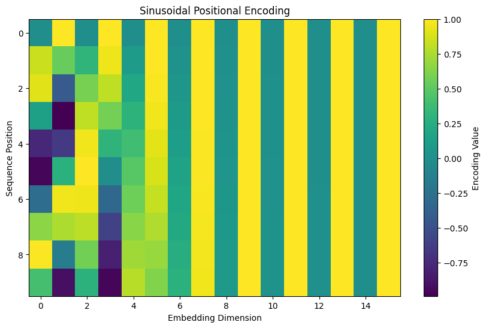

```python
# Visualize the positional encoding as a heatmap
plt.figure(figsize=(10, 6))
plt.imshow(positional_encoding, cmap="viridis", aspect="auto")
plt.colorbar(label="Encoding Value")
plt.title("Sinusoidal Positional Encoding")
plt.xlabel("Embedding Dimension")
plt.ylabel("Sequence Position")
plt.show()
```

# 4B. Analyze the impact of sequence length on its performance.

# Impact of Sequence Length on Sinusoidal Positional Encoding

```python
def cosine_similarity(vec1, vec2):
    """Compute cosine similarity between two vectors."""
    return np.dot(vec1, vec2) / (np.linalg.norm(vec1) * np.linalg.norm(vec2))


def analyze_sequence_length_impact(max_seq_len, d_model):
    """
    Analyze the impact of sequence length on positional encodings.

    Parameters:
    - max_seq_len (int): Maximum sequence length to analyze.
    - d_model (int): Dimensionality of the embeddings.
    """
    lengths = range(10, max_seq_len + 1, 100)
    average_similarities = []

    for seq_len in lengths:
        # Generate positional encodings
        pos_enc = sinusoidal_positional_encoding(seq_len, d_model)

        # Compute similarities between adjacent positions
        similarities = [
            cosine_similarity(pos_enc[i], pos_enc[i + 1]) for i in range(seq_len - 1)
        ]
        average_similarities.append(np.mean(similarities))

    # Plot results
    plt.figure(figsize=(10, 6))
    plt.plot(lengths, average_similarities, marker="o", label="Avg Cosine Similarity")
    plt.axhline(0, color="gray", linestyle="--", linewidth=0.8)
    plt.title("Impact of Sequence Length on Positional Encoding")
    plt.xlabel("Sequence Length")
    plt.ylabel("Average Cosine Similarity (Adjacent Positions)")
    plt.legend()
    plt.grid()
    plt.show()
```

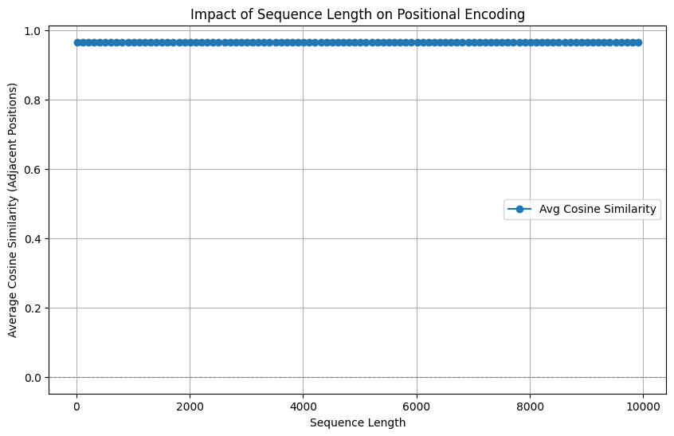

```python
# Analyze with example parameters
analyze_sequence_length_impact(max_seq_len=10000, d_model=64)
```